# HDAT9600 Linear Models Assignment

Submission deadline - See Course Timetable

11 三月, 2024

## Instructions

This file is the R Markdown document in which you need to complete your HDAT9600 Linear Models assignment. This assignment is assessed and will count for 20% of the total course mark.

You should complete ALL the tasks described below, in the spaces provided. Don’t hesitate to ask for help (via OpenLearning @heidiwelberry) — but remember that these are **individual** assignments and thus what you submit should be your own work, and you need to both understand and be able to explain what you did in your solutions.

Each task below attracts the indicated number of marks (out of a total of 20 marks for the assignment).

### Marking hints and tips

Marks will be awarded as indicated for each question. Make sure your R code is neat and easy to follow. Where the answer requires interpretation and discussion, you can keep this brief but DO try to include evidence for your statements by referencing the specific results which support your conclusions. Where the answer requires production of a plot, make sure to label all axes with clear labels and give the plot a title.

## Task 1 (10 marks)

In Task 1 of this assignment, you will be using a dataset called `body` which is a modified version of the `fat` dataset from the Faraway package in R. You will need to download the file `body.csv` from Open Learning and read it in using the read.csv() command in the first code chunk below. Age, weight, height, and 6 body circumference measurements are recorded for 200 men. Each man’s percentage of body fat was accurately estimated by an underwater weighing technique. A summary of the variables is provided below:

pct - Percent body fat (%)  
age - Age(yrs)  
weight - Weight(lbs)  
height - Height(inches)  
neck - Neck circumference(cm)  
chest - Chest circumference(cm)  
abdom - Abdomen circumference(cm) at the umbilicus and level with the iliac crest  
hip - Hip circumference(cm)  
thigh - Thigh circumference(cm)  
biceps - Extended biceps circumference(cm)

Task 1 Set-Up

```r
# this loads the body dataset and makes it available for code in
# subsequent code chunks.
# set your working folder where the datasets are stored
mydat <- file.path("C:/Users/froze/OneDrive/Documents/2.1 UNSW bioinfo/HDAT9600/Assignment/Ass1")

body <- read.csv(file.path(mydat, "body.csv"))
```

1. Fit a linear regression model to the `body` dataset using `pct` as the outcome (response) variable including all other variables as predictors. Call this model `full.mod`. Print the summary output for this model (0.5 marks)

```r
# insert your R code (with comment lines if you wish) here
# The .  means "all other variables in the data frame
full.mod <- lm(pct ~ ., data = body)
summary(full.mod)
```

```
##
## Call:
## lm(formula = pct ~ ., data = body)
##
## Residuals:
##     Min      1Q  Median      3Q     Max
## -6.8265 -2.8136  0.1953  2.5653  7.1274
##
## Coefficients:
##             Estimate Std. Error t value Pr(>|t|)
## (Intercept) 49.19874   35.34625   1.392  0.16558
## age          0.14526    0.08553   1.698  0.09109 .
## height      -0.93726    0.33708  -2.780  0.00597 **
## weight       0.02273    0.10398   0.219  0.82719
## neck        -0.09062    0.21811  -0.415  0.67827
## chest       -0.46392    0.11652  -3.981 9.75e-05 ***
## abdom        0.73816    0.09742   7.577 1.51e-12 ***
## hip         -0.04925    0.16773  -0.294  0.76935
## thigh        0.20663    0.16882   1.224  0.22249
## biceps       0.01002    0.25889   0.039  0.96917
## ---
## Signif. codes:  0 '***' 0.001 '**' 0.01 '*' 0.05 '.' 0.1 ' ' 1
##
## Residual standard error: 3.539 on 190 degrees of freedom
## Multiple R-squared:  0.6977, Adjusted R-squared:  0.6834
## F-statistic: 48.73 on 9 and 190 DF,  p-value: < 2.2e-16
```

2. Compute and display the 95% and 90% confidence intervals for the `age` variable in the full model. (Hint: examine the manual (help) page for the `confint()` function.) (0.5 marks)

```r
# insert your R code (with comment lines if you wish) here
# 95% confidence interval for the age variable
confint(full.mod, "age", level = 0.95)
```

```
##           2.5 %    97.5 %
## age -0.02345403 0.3139707
```

```r
# 90% confidence interval for the age variable
confint(full.mod, "age", level = 0.90)
```

```
##             5 %      95 %
## age 0.003882989 0.2866337
```

3. What does your output from parts a AND b tell you about the relationship between age and percent body fat (1 mark). *Estimate coefficient of age is 0.14526, which means when holding all other variables constant each additional year of age is associated with an increase of 0.14526% in body fat percentage(pct).* *Standard error is 0.08553 indicating the variability of the age coefficient estimate.* *The t-value for age is 1.698. This value is used to determine the statistical significance of the coefficient. The null hypothesis in this case states that the specific predictor (age) has no effect on the dependent variable (percent body fat). Assuming the null hypothesis is true, the t-value (Estimate for age: 0.14526 / Standard Error for age: 0.08553) is a measure of how many standard deviations the coefficient is away from zero. A higher absolute value of the t-value indicates a greater likelihood that the variable is impact or significant in the model. In this case 1.698 is a moderate value, indicating some influence of age on body fat percentage, but it’s not overwhelmingly strong.* *The p-value for age is 0.09109. In general, a p-value less than 0.05 is considered statistically significant. Here, the p-value is close to 0.10, suggesting a marginal statistical significance. Thus, there is some evidence of a relationship between age and percent body fat, but this evidence is not strong.* *95% Confidence interval include 0, indicates that there is some uncertainty about the significance of the effect of age on pct. In addition, this interval skew towards positive values, it suggests a trend where age might be positively associated with pct.* *90% Confidence interval does not include 0 and is entirely in the positive range, indicates that there is a more confident assertion of age is positively associated with pct at the 90% confidence level.*
4. Fit a second model using `pct` as the outcome and this time include only `age`, `weight`, and `height` (on the basis that these are often stored within a patient’s medical record). Call this model `simple.mod`. Print the summary output for this model (0.5 marks).

```r
# insert your R code (with comment lines if you wish) here
# Fit a simplified linear model
simple.mod <- lm(pct ~ age + weight + height, data = body)
# Print the summary of the simple model
summary(simple.mod)
```

```
##
## Call:
## lm(formula = pct ~ age + weight + height, data = body)
##
## Residuals:
##      Min       1Q   Median       3Q      Max
## -10.5708  -3.9515  -0.1451   2.0138  15.1292
##
## Coefficients:
##             Estimate Std. Error t value Pr(>|t|)
## (Intercept) 77.23397   11.24226   6.870 8.32e-11 ***
## age          0.52285    0.08921   5.861 1.92e-08 ***
## weight       0.17558    0.01778   9.876  < 2e-16 ***
## height      -1.53631    0.16557  -9.279  < 2e-16 ***
## ---
## Signif. codes:  0 '***' 0.001 '**' 0.01 '*' 0.05 '.' 0.1 ' ' 1
##
## Residual standard error: 4.348 on 196 degrees of freedom
## Multiple R-squared:  0.5293, Adjusted R-squared:  0.5221
## F-statistic: 73.46 on 3 and 196 DF,  p-value: < 2.2e-16
```

5. Compare the two models. Hint: look at the section on “Testing pairs of predictors” in Chapter 2. The same method can be used to compare models that differ by more than just two predictors. Comment on whether it is justifiable to use the simple model or not and explain why. (2 marks)

```r
# insert your R code (with comment lines if you wish) here
# Compare the models using an F-test
anova(simple.mod, full.mod)
```

```
## Analysis of Variance Table
##
## Model 1: pct ~ age + weight + height
## Model 2: pct ~ age + height + weight + neck + chest + abdom + hip + thigh +
##     biceps
##   Res.Df    RSS Df Sum of Sq      F    Pr(>F)
## 1    196 3705.4
## 2    190 2379.3  6      1326 17.649 3.279e-16 ***
## ---
## Signif. codes:  0 '***' 0.001 '**' 0.01 '*' 0.05 '.' 0.1 ' ' 1
```

*Res.Df (Residual Degrees of Freedom) indicates the number of observations minus the number of estimated parameters. For Model 1 (simpler model) it is ‘196’ and for Model 2 (full model) it is ‘190’.* *RSS (Residual Sum of Squares) measures the amount of variation in the dependent variable (`pct`) that is not explained by the model. Lower values indicate better model fit. In this case, `3705.4` for the simpler model and `2379.3` for the full model, suggesting full model has better fit.* *Df (Difference in Degrees of Freedom) is 6 which is the difference in the number of predictors between the full model and the simpler model. (6 predictors are `neck`, `chest`, `abdom`, `hip`, `thigh`, and `biceps`)* *Sum of Sq (Difference in Sum of Squares) is 1326, which is the reduction in RSS when moving from the simpler model to the full model.* *F-Statistic is `17.649`, which tests whether the reduction in residual sum of squares (RSS) from Model 1 to Model 2 is significant. It’s calculated based on the difference in RSS between the models, adjusted for the difference in degrees of freedom.* *Pr(>F) (P-value) is `3.279e-16`, which is extremely small (far below 0.05). As this p-value tests the null hypothesis [adding the additional variables (`neck`, `chest`, `abdom`, `hip`, `thigh`, `biceps`) to the simpler model does not significantly improve the fit of the model], we can reject the null hypothesis . This means that the additional variables in the full model significantly improve the model’s fit compared to the simpler model. The full model explains more variability in the percent body fat than the simpler model and provides a better understanding of the percent body fat.Therefore, from a statistical perspective, it is justified to use the full model over the simpler model for predicting percent body fat. However, the decision to use a more complex model should also consider factors like the interpretability of the model, the availability of data in practical scenarios, and the specific needs of the analysis et al.*

6. Compute a 95% **prediction** interval for the **mean** (not median) predictor values for the full and reduced models, and write a single sentence comparing the intervals. Do the intervals vary by much? (2 marks)

```r
# insert your R code (with comment lines if you wish) here
# Calculate mean values for all predictors
# 'na.rm = TRUE' ensures that missing values (NA) are ignored in the mean calculation.
mean_values <- with(body, data.frame(
  age = mean(age, na.rm = TRUE),
  weight = mean(weight, na.rm = TRUE),
  height = mean(height, na.rm = TRUE),
  neck = mean(neck, na.rm = TRUE),
  chest = mean(chest, na.rm = TRUE),
  abdom = mean(abdom, na.rm = TRUE),
  hip = mean(hip, na.rm = TRUE),
  thigh = mean(thigh, na.rm = TRUE),
  biceps = mean(biceps, na.rm = TRUE)
))

# Compute the 95% prediction interval for the full via predict() function
predict(full.mod, newdata = mean_values, interval = "prediction", level = 0.95)
```

```
##      fit      lwr      upr
## 1 16.026 9.028308 23.02369
```

```r
# Compute the 95% prediction interval for the simple model
predict(simple.mod, newdata = mean_values, interval = "prediction", level = 0.95)
```

```
##      fit      lwr      upr
## 1 16.026 7.429775 24.62222
```

*For both models, the `fit` value (predicted percent body fat) at the mean values of the predictors is 16.026. This means that, on average, an individual with mean characteristics (as defined by the predictors in each model) is expected to have a body fat percentage of approximately 16.026%. It also indicates a same/similar predicted outcome from both models when considering the average case.* *Width of Prediction Intervals: The interval range of full Model is about 9% to 23% body fat, the interval range of simple Model is about 7% to 25% body fat. full model’s prediction interval is narrower, suggesting it provides more precise predictions for the average individual compared to the simplified model. The prediction interval for the simplified model is slightly wider than for the full model. This implies that there’s more uncertainty in the predictions when only age, weight, and height are considered, compared to when all the predictors are included. The difference in interval widths is noticeable but not extreme, indicating both models provide reasonably accurate predictions for percent body fat with mean predictor values, the full model offers a bit more precision and the simple model has simplicity and ease of data collection.*

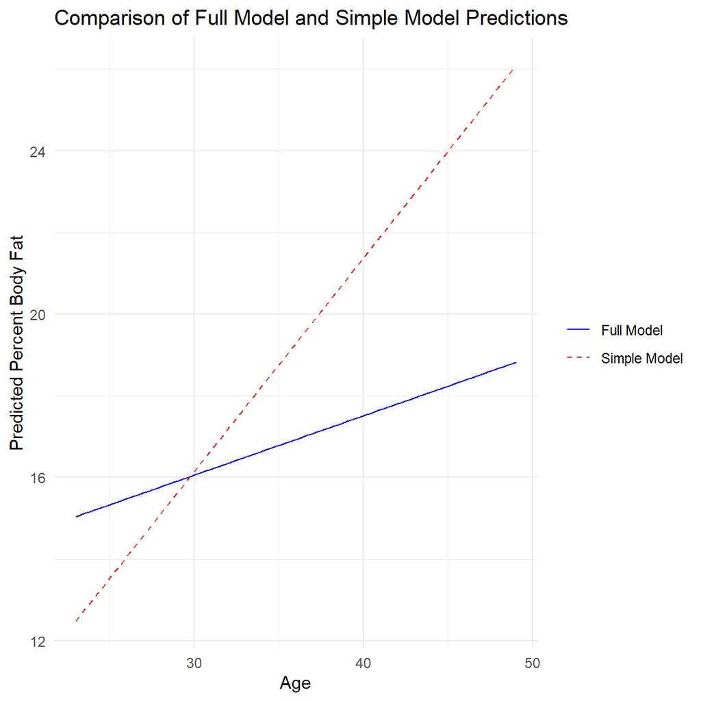

```r
library(ggplot2)
# Create a range of values for age
age_range <- seq(min(body$age, na.rm = TRUE), max(body$age, na.rm = TRUE), length.out = 100)

# Data frame for predictions from the full model
df_full <- with(body, data.frame(
  age = age_range,
  weight = mean(weight, na.rm = TRUE),
  height = mean(height, na.rm = TRUE),
  neck = mean(neck, na.rm = TRUE),
  chest = mean(chest, na.rm = TRUE),
  abdom = mean(abdom, na.rm = TRUE),
  hip = mean(hip, na.rm = TRUE),
  thigh = mean(thigh, na.rm = TRUE),
  biceps = mean(biceps, na.rm = TRUE)
))
df_full$pct_pred <- predict(full.mod, newdata = df_full)

# Data frame for predictions from the simple model
df_simple <- data.frame(
  age = age_range,
  weight = mean(body$weight, na.rm = TRUE),
  height = mean(body$height, na.rm = TRUE)
)
df_simple$pct_pred <- predict(simple.mod, newdata = df_simple)

# Create the effect plot
ggplot() +
  geom_line(data = df_full, aes(x = age, y = pct_pred, color = "Full Model")) +
  geom_line(data = df_simple, aes(x = age, y = pct_pred, color = "Simple Model"), linetype = "dashed") +
  labs(x = "Age", y = "Predicted Percent Body Fat", title = "Effect of Age on Predicted Body Fat Percentage") +
  scale_color_manual(values = c("Full Model" = "blue", "Simple Model" = "red")) +
  theme_minimal() +
  ggtitle("Comparison of Full Model and Simple Model Predictions") +
  theme(legend.title = element_blank())
```

7. Repeat Part g. but this time for the **confidence** intervals for the **mean** (not median) predictor values for the full and reduced models, and again write a single sentence comparing the intervals. Do the intervals vary by much? (2 marks)

```r
# insert your R code (with comment lines if you wish) here
# Compute the 95% prediction interval for the full model
predict(full.mod, newdata = mean_values, interval = "confidence", level = 0.95)
```

```
##      fit      lwr      upr
## 1 16.026 15.53242 16.51958
```

```r
# Compute the 95% prediction interval for the simple model
predict(simple.mod, newdata = mean_values, interval = "confidence", level = 0.95)
```

```
##      fit      lwr      upr
## 1 16.026 15.41967 16.63233
```

*For both models, the `fit` value (predicted percent body fat) at the mean values of the predictors is 16.026. This means that, on average, an individual with mean characteristics (as defined by the predictors in each model) is expected to have a body fat percentage of approximately 16.026%. It also indicates a same/similar predicted outcome from both models when considering the average case.* *The interval span of full model is approximately 0.988% and the interval span of simple model is approximately 1.213%.The confidence interval of both models are similar, the simple model is slightly wider.* *The lesser difference in the width of confidence intervals (Part g) between the full and simple models compared to the prediction intervals (Part f) is because confidence intervals only consider the uncertainty in estimating the mean response. On the other hand, prediction intervals reflect the variability of actual data points around the predicted mean. Here, the full model’s additional predictors help capture more of this variability, leading to narrower intervals and a more noticeable difference from the simplified model.*

8. Using the simple model, identify the three observations with the greatest Cook’s distance. Remove (or exclude) those observations from the dataset and re-fit the simple model. Comment on any differences you see in the model summary (if any). (1.5 marks) *(Note: updated March 4th to say three observations. If you have identified two observations this will also be marked correct)*

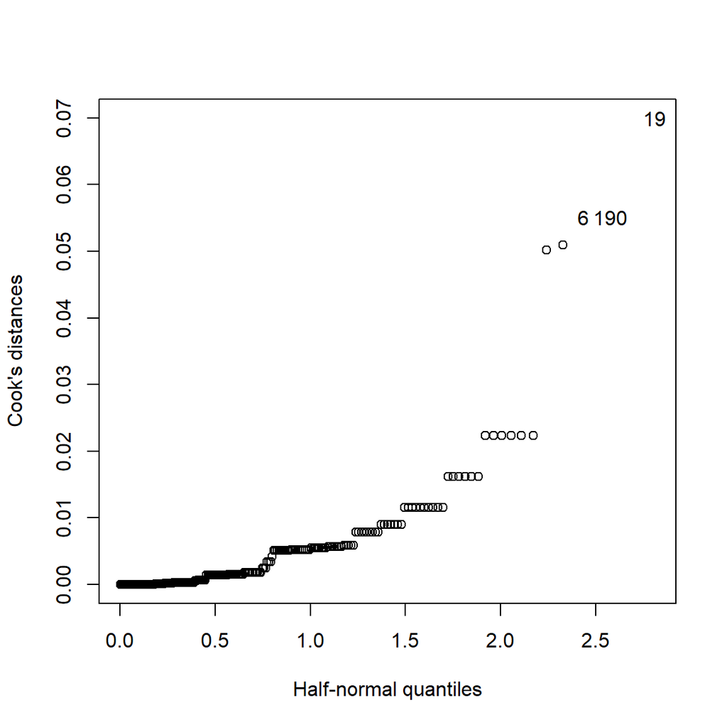

```r
# insert your R code (with comment lines if you wish) here
# Calculate Cook's distances for the simple model
cooks.distances <- cooks.distance(simple.mod)
faraway::halfnorm(cooks.distances, 3, ylab="Cook's distances")
```

```r
# Order the observations by their Cook's distance and select the top three
high.cooks <- order(cooks.distances, decreasing = TRUE)[1:3]

# Remove the three most influential observations from the dataset
body_reduced <- body[-high.cooks, ]

# Refit the simple model without the most influential observations
simple.mod.reduced <- lm(pct ~ age + weight + height, data = body_reduced)

# Output the summaries of the simple model and the new model
summary(simple.mod)
```

```
##
## Call:
## lm(formula = pct ~ age + weight + height, data = body)
##
## Residuals:
##      Min       1Q   Median       3Q      Max
## -10.5708  -3.9515  -0.1451   2.0138  15.1292
##
## Coefficients:
##             Estimate Std. Error t value Pr(>|t|)
## (Intercept) 77.23397   11.24226   6.870 8.32e-11 ***
## age          0.52285    0.08921   5.861 1.92e-08 ***
## weight       0.17558    0.01778   9.876  < 2e-16 ***
## height      -1.53631    0.16557  -9.279  < 2e-16 ***
## ---
## Signif. codes:  0 '***' 0.001 '**' 0.01 '*' 0.05 '.' 0.1 ' ' 1
##
## Residual standard error: 4.348 on 196 degrees of freedom
## Multiple R-squared:  0.5293, Adjusted R-squared:  0.5221
## F-statistic: 73.46 on 3 and 196 DF,  p-value: < 2.2e-16
```

```r
summary(simple.mod.reduced)
```

```
##
## Call:
## lm(formula = pct ~ age + weight + height, data = body_reduced)
##
## Residuals:
##     Min      1Q  Median      3Q     Max
## -7.3206 -3.6497 -0.1375  1.6123  9.2227
##
## Coefficients:
##             Estimate Std. Error t value Pr(>|t|)
## (Intercept) 76.48201   10.58435   7.226 1.13e-11 ***
## age          0.56869    0.08421   6.753 1.65e-10 ***
## weight       0.17155    0.01647  10.417  < 2e-16 ***
## height      -1.53607    0.15456  -9.938  < 2e-16 ***
## ---
## Signif. codes:  0 '***' 0.001 '**' 0.01 '*' 0.05 '.' 0.1 ' ' 1
##
## Residual standard error: 4.024 on 193 degrees of freedom
## Multiple R-squared:  0.5814, Adjusted R-squared:  0.5749
## F-statistic: 89.36 on 3 and 193 DF,  p-value: < 2.2e-16
```

*The range of residuals has decreased (`Min` from -10.5708 to -7.3206 and `Max` from 15.1292 to 9.2227), indicating a reduction in extreme values, which suggests that the model may now be providing a better fit to the majority of the data.*

*The estimate coefficient for `age` has increased slightly (from 0.52285 to 0.56869), suggesting that, after removing the influential points, age has a slightly stronger relationship with percent body fat.* *The estimate coefficients for `weight` and `height` are quite stable, basically unchanged.*

*Residual standard error has decreased from 4.348 to 4.024, which implies that the predictions are now, on average, closer to the actual values.*

*Both the Multiple R-squared and Adjusted R-squared values have increased (from 0.5293 to 0.5814 and from 0.5221 to 0.5749, respectively), indicating that the model without the top 3 influential observations explains a higher proportion of the variance in percent body fat.*

*The F-statistic has increased from 73.46 to 89.36, the p-value remains extremely small, indicating that the model is still statistically significant and that the overall fit has improved.*

*Removing the 3 observations with the highest Cook’s distances appears to have had a positive impact on the simplified regression model. The overall fit of the model has improved as indicated by higher R-squared values and a lower residual standard error. This suggests that the influential observations may have been outliers or measurement errors or data entry errors.*

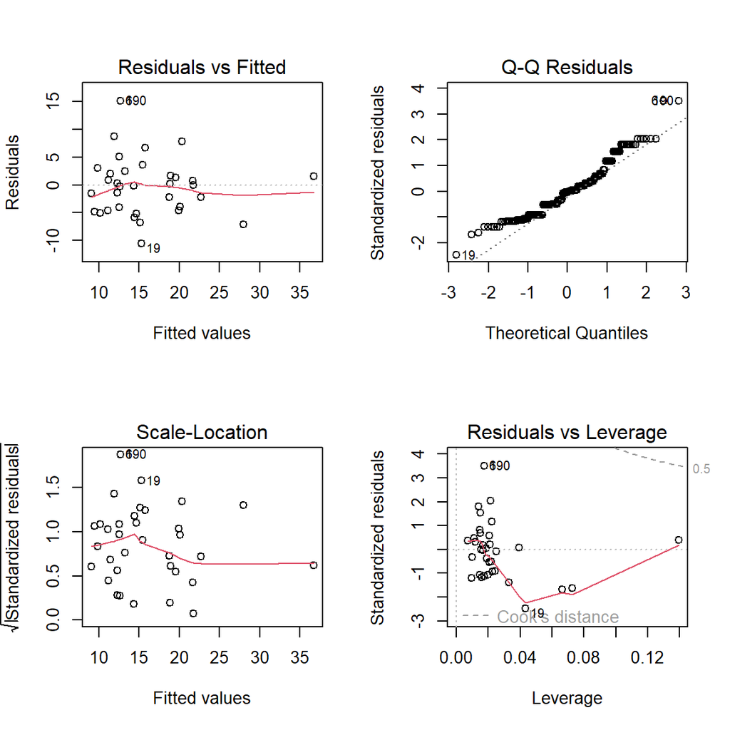

```r
par(mfrow = c(2, 2)) # Set up the graphics to display four plots on one page
plot(simple.mod)
```

## Task 2 (10 marks)

In this task, you will be using a dataset called `hips2` which is a modified version of the `hips` dataset, also from the *faraway* package for R. You will need to download the file hips2.csv from Open Learning and load it in using the first code chunk below.

The `hips2` dataset is adapted from a study undertaken in the 1950s at the [Royal Mineral Hospital](https://en.wikipedia.org/wiki/Royal_National_Hospital_for_Rheumatic_Diseases) (now known as the Royal National Hospital for Rheumatic Diseases) in Bath, UK. The study involved patients with [ankylosing spondylitis](https://en.wikipedia.org/wiki/Ankylosing_spondylitis), an auto-immune disease which causes inflammation and eventual seizing up (ankylosis) of the joints of the spine, and to a lesser extent of the hips and shoulders. Patients were randomly allocated to either a treatment group, in which they received physiotherapy involving daily stretching exercises for their hip joints, or to a control group in which no stretching or other physiotherapy was provided. Hip mobility in terms of flexion (bringing the knee up towards the chest) and rotation (rotating the knee inwards and outwards) were measured on each side (right and left), before the study commenced, and after it was completed. A brief description of the variables is provided below.

fbef - flexion angle before  
faft - flexion angle after  
rbef - rotation angle before  
raft - rotation angle after  
grp - treatment group (a factor with 2 levels: control, treat)  
side - side of the body (a factor with 2 levels: right, left)  
person - id for the individual

Task 2 Set-Up

```r
# this loads the hips dataset and makes it available for code in
# subsequent code chunks.
# note: make sure the hips2 dataset is saved in the same folder that we assigned as "mydat"

hips2 <- read.csv(file.path(mydat, "hips2.csv"))
```

1. Carry out a brief exploratory data analysis, examining each variable, and the relationships between all the variables. How many patients were assigned to each group (treatment or control). Are there differences in the variables between the two groups (treatment and control) or sides (left or right)? Show your code and written explanations. (2.5 marks)

```r
# insert your R code (with comment lines if you wish) here
# Summary statistics for each variable
summary(hips2)
```

```
##       fbef            faft            rbef            raft
##  Min.   : 77.0   Min.   : 88.0   Min.   : 2.00   Min.   : 2.00
##  1st Qu.:105.2   1st Qu.:114.0   1st Qu.:20.00   1st Qu.:25.00
##  Median :114.0   Median :120.0   Median :25.00   Median :30.00
##  Mean   :113.2   Mean   :119.9   Mean   :24.54   Mean   :29.56
##  3rd Qu.:122.0   3rd Qu.:127.0   3rd Qu.:30.00   3rd Qu.:35.00
##  Max.   :135.0   Max.   :138.0   Max.   :48.00   Max.   :50.00
##      grp                side               person
##  Length:70          Length:70          Min.   : 2.00
##  Class :character   Class :character   1st Qu.:10.25
##  Mode  :character   Mode  :character   Median :20.00
##                                        Mean   :20.26
##                                        3rd Qu.:30.50
##                                        Max.   :39.00
```

```r
# Count the number of patients in each group
table(hips2$grp)
```

```
##
## control   treat
##      22      48
```

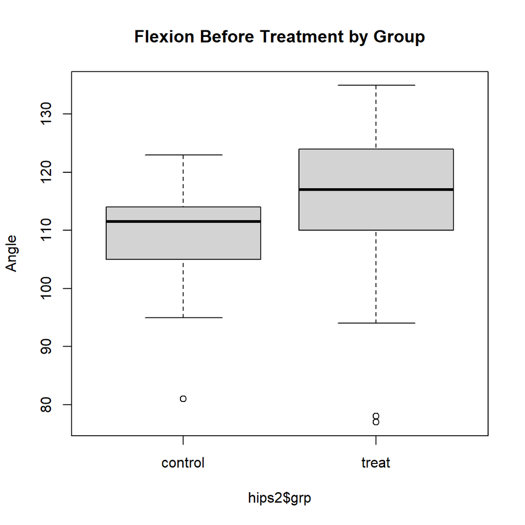

```r
# Boxplots to visualize the distribution of flexion and rotation angles, before and after treatment
boxplot(hips2$fbef ~ hips2$grp, main = "Flexion Before Treatment by Group", ylab = "Angle")
```

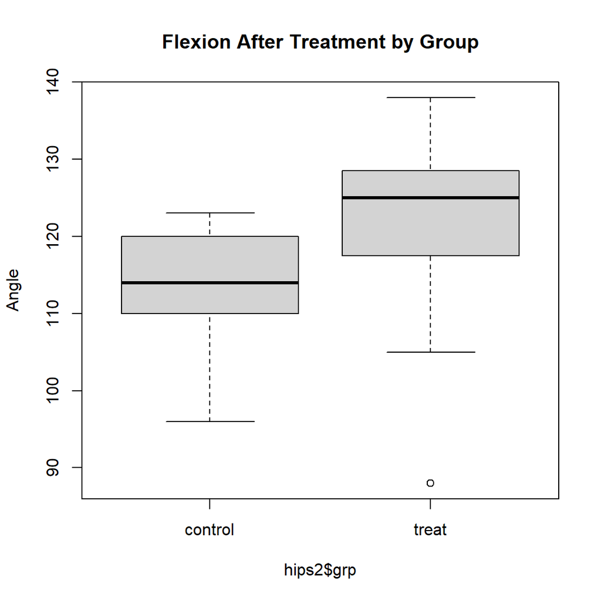

```r
boxplot(hips2$faft ~ hips2$grp, main = "Flexion After Treatment by Group", ylab = "Angle")
```

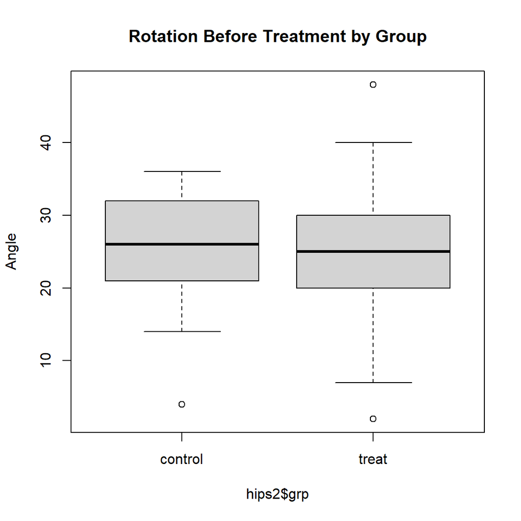

```r
boxplot(hips2$rbef ~ hips2$grp, main = "Rotation Before Treatment by Group", ylab = "Angle")
```

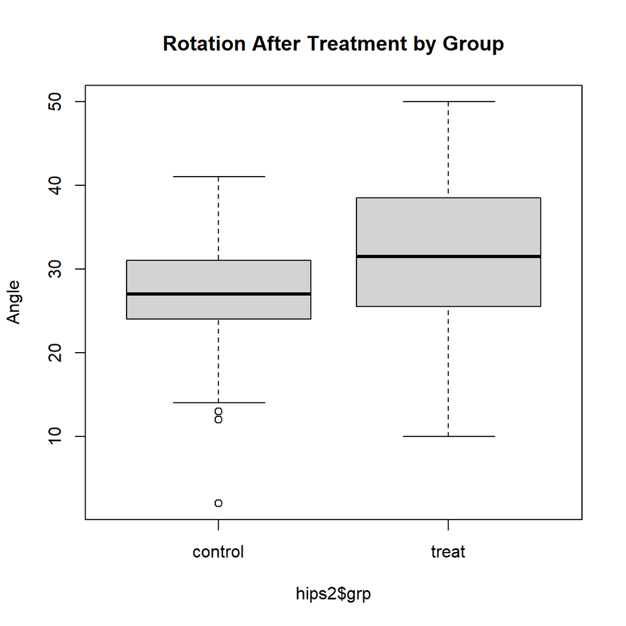

```r
boxplot(hips2$raft ~ hips2$grp, main = "Rotation After Treatment by Group", ylab = "Angle")
```

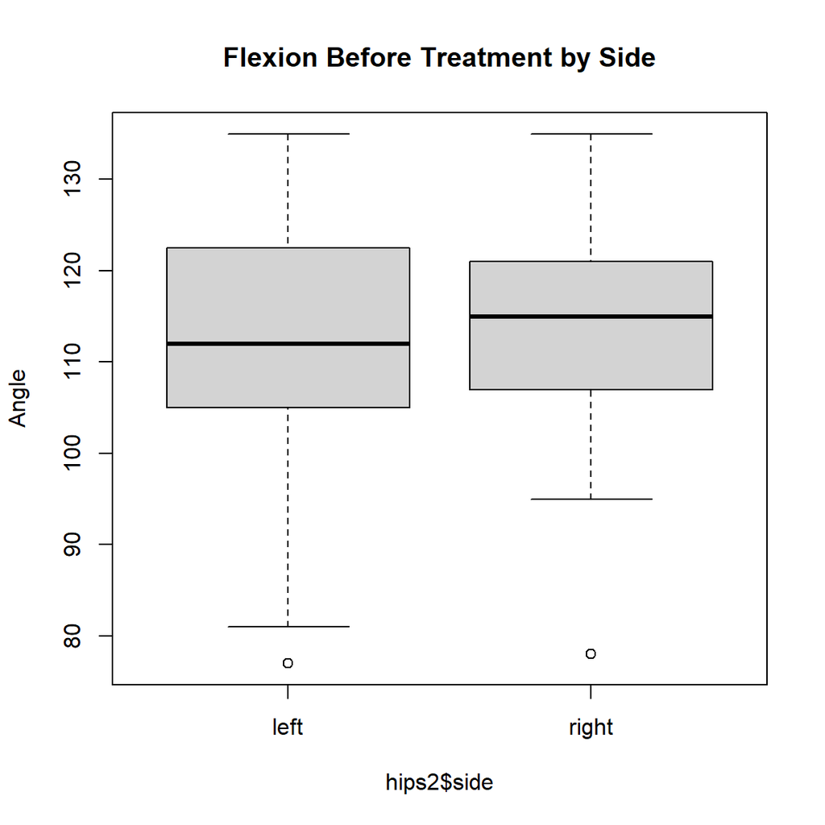

```r
# Boxplots to compare sides
boxplot(hips2$fbef ~ hips2$side, main = "Flexion Before Treatment by Side", ylab = "Angle")
```

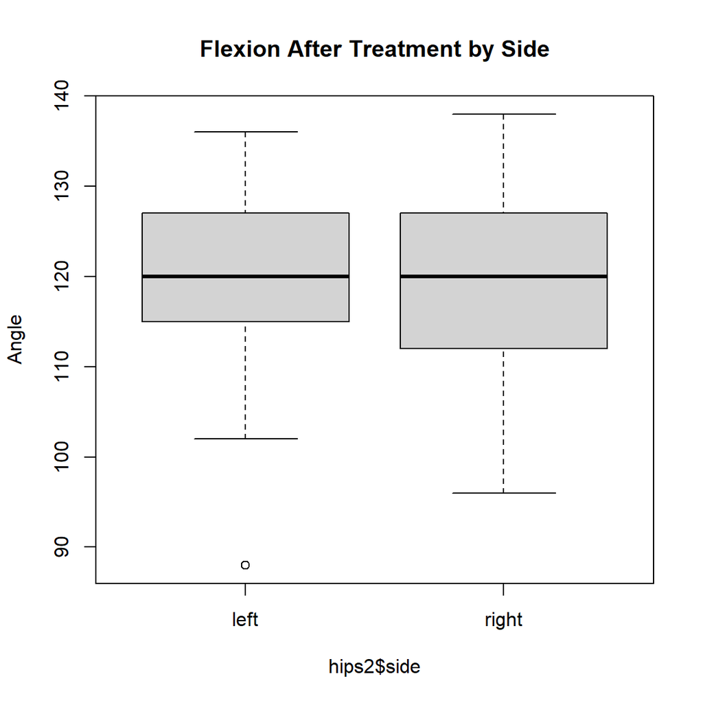

```r
boxplot(hips2$faft ~ hips2$side, main = "Flexion After Treatment by Side", ylab = "Angle")
```

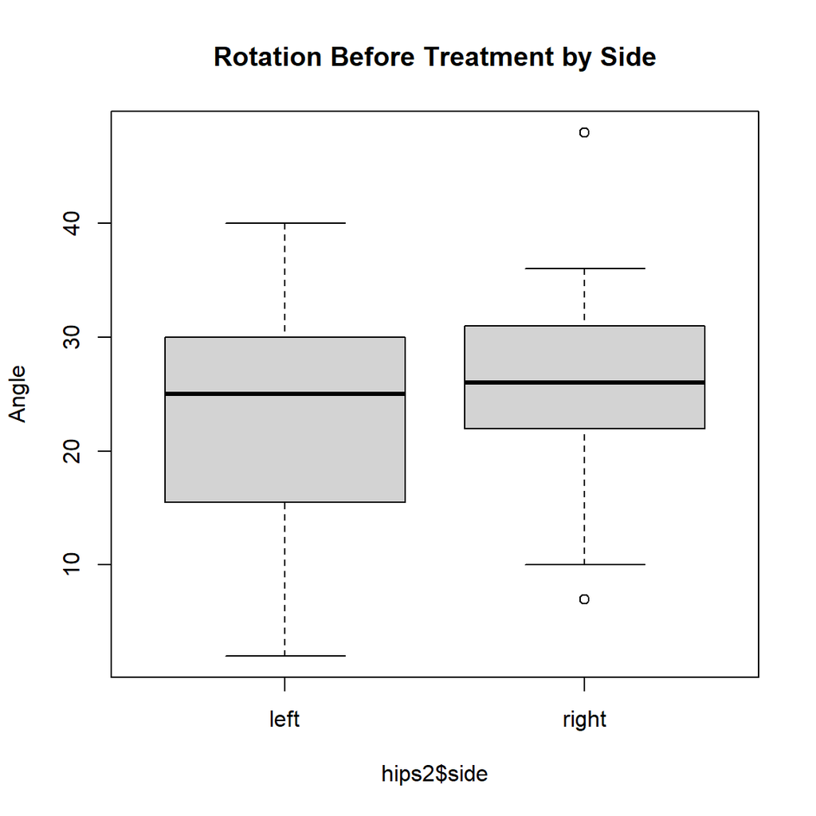

```r
boxplot(hips2$rbef ~ hips2$side, main = "Rotation Before Treatment by Side", ylab = "Angle")
```

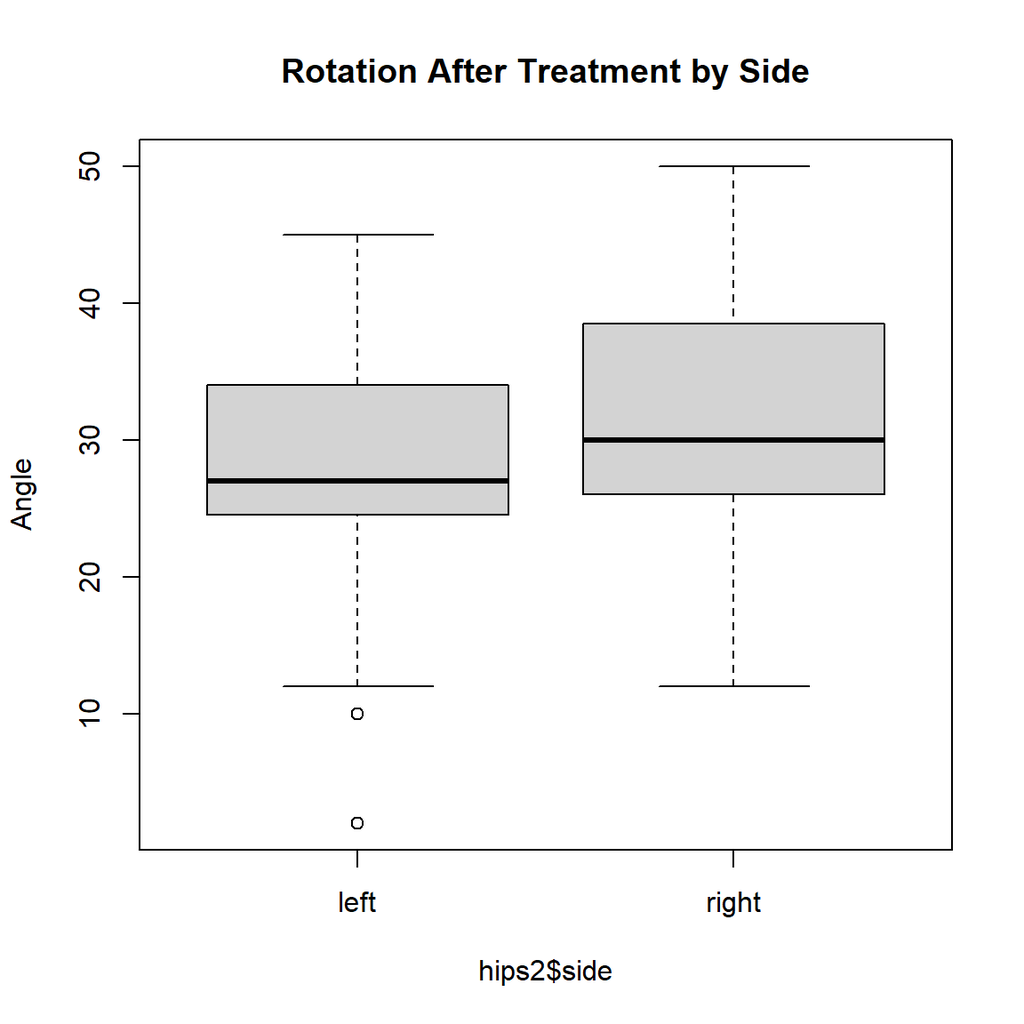

```r
boxplot(hips2$raft ~ hips2$side, main = "Rotation After Treatment by Side", ylab = "Angle")
```

*These boxplots help to investigate the symmetry in the condition’s progression and the treatment’s effects.* *The symptoms of ankylosing spondylitis are symmetrical.* *In general, as indicated by the increases in median values post-treatment, the treatment appears to have a positive effect on both flexion and rotation.*

```r
# Pairwise comparisons between groups for each measurement
t.test(hips2$fbef ~ hips2$grp)
```

```
##
##  Welch Two Sample t-test
##
## data:  hips2$fbef by hips2$grp
## t = -2.5524, df = 55.323, p-value = 0.01349
## alternative hypothesis: true difference in means between group control and group treat is not equal to 0
## 95 percent confidence interval:
##  -11.917204  -1.435069
## sample estimates:
## mean in group control   mean in group treat
##              108.6364              115.3125
```

```r
t.test(hips2$faft ~ hips2$grp)
```

```
##
##  Welch Two Sample t-test
##
## data:  hips2$faft by hips2$grp
## t = -4.8979, df = 51.25, p-value = 1.01e-05
## alternative hypothesis: true difference in means between group control and group treat is not equal to 0
## 95 percent confidence interval:
##  -14.496272  -6.068122
## sample estimates:
## mean in group control   mean in group treat
##              112.8636              123.1458
```

```r
t.test(hips2$rbef ~ hips2$grp)
```

```
##
##  Welch Two Sample t-test
##
## data:  hips2$rbef by hips2$grp
## t = 0.27992, df = 46.989, p-value = 0.7808
## alternative hypothesis: true difference in means between group control and group treat is not equal to 0
## 95 percent confidence interval:
##  -3.714493  4.915251
## sample estimates:
## mean in group control   mean in group treat
##              24.95455              24.35417
```

```r
t.test(hips2$raft ~ hips2$grp)
```

```
##
##  Welch Two Sample t-test
##
## data:  hips2$raft by hips2$grp
## t = -2.3355, df = 39.023, p-value = 0.02475
## alternative hypothesis: true difference in means between group control and group treat is not equal to 0
## 95 percent confidence interval:
##  -10.2986716  -0.7392072
## sample estimates:
## mean in group control   mean in group treat
##              25.77273              31.29167
```

*In Flexion Before Treatment t-test result, the p-value is 0.01349, which is less than the standard alpha level of 0.05, indicating that there is a statistically significant difference in the mean flexion angles between the control and treatment groups before treatment , which could confound the results.* *In Flexion After Treatment t-test result, the p-value is very small (1.01e-05), much less than the standard alpha level of 0.05, suggesting a highly significant difference in mean flexion angles between the two groups after treatment. This also supports the potential effectiveness of the treatment.* *In Rotation Before Treatment t-test result, the p-value is 0.7808, which is higher than the standard alpha level of 0.05, meaning there is no significant difference in the mean rotation angles between the control and treatment groups before treatment.* *In Rotation After Treatment t-test result, the p-value is 0.02475, which is less than the standard alpha level of 0.05, indicating a statistically significant difference in the mean rotation angles after treatment between the control and treatment groups. Again, it supports the potential effectiveness of the treatment.*

```r
# Pairwise comparisons between sides for each group
t.test(hips2$fbef ~ hips2$side)
```

```
##
##  Welch Two Sample t-test
##
## data:  hips2$fbef by hips2$side
## t = -0.27172, df = 67.464, p-value = 0.7867
## alternative hypothesis: true difference in means between group left and group right is not equal to 0
## 95 percent confidence interval:
##  -6.437399  4.894541
## sample estimates:
##  mean in group left mean in group right
##            112.8286            113.6000
```

```r
t.test(hips2$faft ~ hips2$side)
```

```
##
##  Welch Two Sample t-test
##
## data:  hips2$faft by hips2$side
## t = 0.094198, df = 67.997, p-value = 0.9252
## alternative hypothesis: true difference in means between group left and group right is not equal to 0
## 95 percent confidence interval:
##  -4.613427  5.070570
## sample estimates:
##  mean in group left mean in group right
##            120.0286            119.8000
```

```r
t.test(hips2$rbef ~ hips2$side)
```

```
##
##  Welch Two Sample t-test
##
## data:  hips2$rbef by hips2$side
## t = -1.4027, df = 66.585, p-value = 0.1654
## alternative hypothesis: true difference in means between group left and group right is not equal to 0
## 95 percent confidence interval:
##  -7.061749  1.233177
## sample estimates:
##  mean in group left mean in group right
##            23.08571            26.00000
```

```r
t.test(hips2$raft ~ hips2$side)
```

```
##
##  Welch Two Sample t-test
##
## data:  hips2$raft by hips2$side
## t = -2.1477, df = 66.689, p-value = 0.03538
## alternative hypothesis: true difference in means between group left and group right is not equal to 0
## 95 percent confidence interval:
##  -8.9858070 -0.3284787
## sample estimates:
##  mean in group left mean in group right
##            27.22857            31.88571
```

*In Rotation After Treatment by Side t-test result, the p-value is 0.03538, which is below the standard threshold of 0.05, indicating a statistically significant difference in post-treatment rotation angles between the left and right sides with the right side having a higher mean angle post-treatment. This could suggest that the treatment has a different effect on rotation depending on the side, or it could be due to natural variability or other factors not accounted for in the analysis.*

Add additional code blocks and text blocks as needed.

2. Create two new variables, called `flexdiff` and `rotdiff`, which contain the difference between the before and after flexion, or the before and after rotation, respectively. Use histograms to show the distribution of these new variables for each of the two groups (treatment or control). What do you observe? (1 mark)

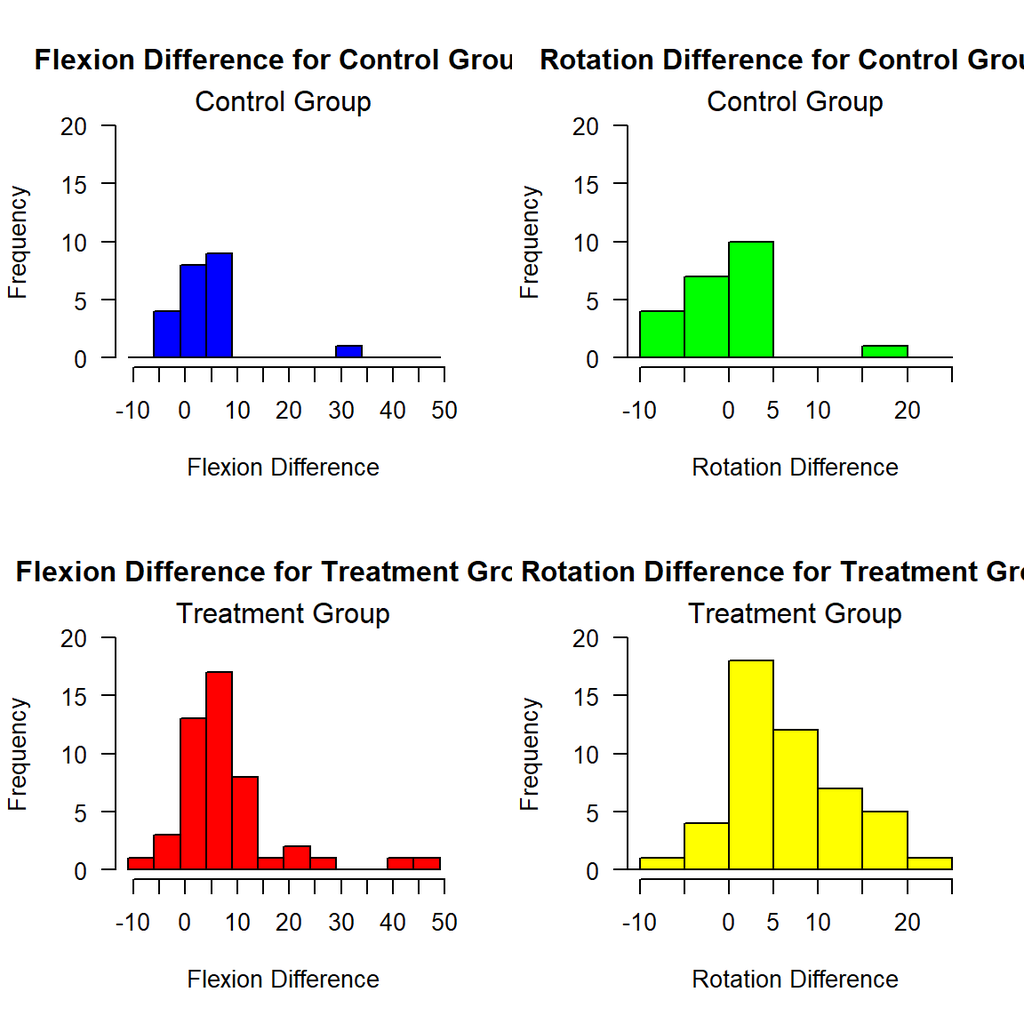

```r
# insert your R code (with comment lines if you wish) here
# Create the `flexdiff` and `rotdiff` variables
hips2$flexdiff <- hips2$faft - hips2$fbef
hips2$rotdiff <- hips2$raft - hips2$rbef

#table(hips2$flexdiff[hips2$grp == "control"])
#table(hips2$flexdiff[hips2$grp == "treat"])

layout(matrix(c(1, 3, 2, 4), nrow=2, byrow=TRUE), widths = c(1, 1), heights = c(1, 1))
par(mar = c(5, 4, 4, 2) + 0.1)  # Adjust the numbers as necessary for your specific case

# Calculate breaks for histograms
flexdiff_min <- min(hips2$flexdiff)
flexdiff_max <- max(hips2$flexdiff)
rotdiff_min <- min(hips2$rotdiff)
rotdiff_max <- max(hips2$rotdiff)

# Ensure breaks span slightly beyond the min and max
flexdiff_breaks <- seq(floor(flexdiff_min), ceiling(flexdiff_max), by=5)
#rotdiff_breaks <- seq(floor(rotdiff_min), ceiling(rotdiff_max)+1, by=5)
rotdiff_breaks <- seq(from = -15, to = 25, by = 5)

#print(hips2$rotdiff[hips2$grp == "treat"])
#print(rotdiff_breaks)


# Upper Plot flexdiff (Control Group)
hist(hips2$flexdiff[hips2$grp == "control"],
     breaks = flexdiff_breaks,
     main = "Flexion Difference for Control Group",
     xlab = "Flexion Difference",
     ylab = "Frequency",
     col = "blue",
     ylim = c(0, 20),
     axes = FALSE)
axis(2, las=1)
axis(1, at=seq(from=min(hips2$flexdiff)+1, to=max(hips2$flexdiff)+1, by=5))
mtext("Control Group", side=3, line=0)

# Lower Plot flexdiff (Treatment Group)
hist(hips2$flexdiff[hips2$grp == "treat"],
     breaks = flexdiff_breaks,
     main = "Flexion Difference for Treatment Group",
     xlab = "Flexion Difference",
     ylab = "Frequency",
     col = "red",
     ylim = c(0, 20),
     axes = FALSE)
axis(2, las=1)
axis(1, at=seq(from=min(hips2$flexdiff)+1, to=max(hips2$flexdiff)+1, by=5))
mtext("Treatment Group", side=3, line=0)


# Upper Plot rotdiff (Control Group)
hist(hips2$rotdiff[hips2$grp == "control"],
     breaks = rotdiff_breaks,
     main = "Rotation Difference for Control Group",
     xlab = "Rotation Difference",
     ylab = "Frequency",
     col = "green",
     ylim = c(0, 20), xlim = c(-10, 25),
     axes = FALSE)
axis(2, las=1)
axis(1, at=seq(from=-10, to=25, by=5))
mtext("Control Group", side=3, line=0)

# Lower Plot rotdiff (Treatment Group)
hist(hips2$rotdiff[hips2$grp == "treat"],
     breaks = rotdiff_breaks,
     main = "Rotation Difference for Treatment Group",
     xlab = "Rotation Difference",
     ylab = "Frequency",
     col = "yellow",
     ylim = c(0, 20), xlim = c(-10, 25),
     axes = FALSE)
axis(2, las=1)
axis(1, at=seq(from=-10, to=25, by=5))
mtext("Treatment Group", side=3, line=0)
```

```r
# Reset the graphical parameters to default
par(mfrow = c(1, 1), mar = rep(5, 4))
```

*Four histograms represent the distribution of differences in flexion and rotation angles before and after the treatment for both control and treatment groups.* *Flexion Difference for Control Group (Blue Histogram): The majority of differences are clustered around a small positive value, suggesting slight improvements in the flexion angle for most control group subjects.* *Flexion Difference for Treatment Group (Red Histogram): This group shows a wide spread in the distribution of flexion differences, with a significant number of subjects experiencing improvements, as evidenced by the higher frequency of larger positive values. The highest peak is between 5 to 10, indicating a considerable improvement in flexion angles after treatment.* *Rotation Difference for Control Group (Green Histogram): The distribution is fairly uniform across different categories, with a slightly higher frequency of instances showing small improvements in rotation. However, there is a notable frequency for a difference of 0, indicating no change in a significant number of subjects.* *Rotation Difference for Treatment Group (Yellow Histogram): The distribution suggests varied responses to treatment with most changes being positive, indicating improved rotation. There is a notable peak in the frequency for smaller positive differences, with a gradual decrease in frequency for larger differences.* *Over all, These four histograms suggest that the treatment was generally effective in improving both flexion and rotation, as more so for the treatment group than for the control group.*

3. The data set contains two observations for each patient — one for the right hip, and one for the left hip. If we fit standard linear regression models using OLS, should we analyse all the data in one model, or should we fit two separate models, one for the right side hips and the other for the left side hips, or should we fit one model and include the `side` variable as a predictor? Justify your answer based on the assumptions we rely on for OLS linear models. (1.5 marks)

*When fitting standard linear regression models using OLS (Ordinary Least Squares), there are some assumptions must be considered, including:* *Independence - If the measurements from the right and left hips of the same patient are correlated (which is often the case as they are from the same person), this violates the OLS assumption of independence of errors. This suggests that a single model for all data might not be appropriate unless this within-subject correlation is accounted for.* *Homoscedasticity - The variance of error terms is constant across all levels of the independent variables.* *No multicollinearity - Independent variables are not highly correlated with each other.* *Normality - The residuals of the model are normally distributed.*

*If analyse all data in one model:* *It could violate the independence assumption because the observations from the same patient are likely to be correlated.*

*If fit two separate models:* *It allows for the modeling of potentially different relationships on each side.* *Tt would not allow for a direct comparison between the right and left sides.* *It does not directly address the independence issue either as the same patient’s measurements would be split across two models.*

*If incorporating ‘side’ as a Predictor in a single model:* *It would allow for direct comparison and control for the side of the body in the analysis, to account for systematic differences between right and left hips.* *It could still violate the independence assumption unless the model accounts for the repeated measures on the same individuals.* *It still may not adequately account for the within-patient correlation between the two measurements.*

*(Please not include this as part of my answer) # A better approach would be using a mixed-effects model (or multilevel model) which can account for the non-independence of observations from the same patient by including random effects.*

4. Fit a model to the data for right-side hips only. Use `flexdiff` as the outcome, and the `grp` variable as a sole predictor. Report on whether there appears to be a treatment effect. Repeat this for the left hips. (1 mark)

```r
# insert your R code (with comment lines if you wish) here
# Flexion difference model for right-side hips
right_flex <- lm(flexdiff ~ grp, data = hips2[hips2$side == "right",])
summary(right_flex)
```

```
##
## Call:
## lm(formula = flexdiff ~ grp, data = hips2[hips2$side == "right",
##     ])
##
## Residuals:
##     Min      1Q  Median      3Q     Max
## -12.333  -3.030  -0.727   1.667  35.667
##
## Coefficients:
##             Estimate Std. Error t value Pr(>|t|)
## (Intercept)    3.727      2.262   1.648    0.109
## grptreat       3.606      2.732   1.320    0.196
##
## Residual standard error: 7.503 on 33 degrees of freedom
## Multiple R-squared:  0.05016,    Adjusted R-squared:  0.02137
## F-statistic: 1.743 on 1 and 33 DF,  p-value: 0.1959
```

```r
# For left-side hips
left_flex <- lm(flexdiff ~ grp, data = hips2[hips2$side == "left",])
summary(left_flex)
```

```
##
## Call:
## lm(formula = flexdiff ~ grp, data = hips2[hips2$side == "left",
##     ])
##
## Residuals:
##     Min      1Q  Median      3Q     Max
## -19.333  -6.530  -2.333   2.970  40.667
##
## Coefficients:
##             Estimate Std. Error t value Pr(>|t|)
## (Intercept)    4.727      3.403   1.389    0.174
## grptreat       3.606      4.109   0.878    0.387
##
## Residual standard error: 11.29 on 33 degrees of freedom
## Multiple R-squared:  0.0228, Adjusted R-squared:  -0.00681
## F-statistic:  0.77 on 1 and 33 DF,  p-value: 0.3866
```

*For the right-side hips, the treatment effect has an estimated increase of 3.606 degrees in flexion difference, but with a p-value of 0.196, which is not statistically significant at the typical p-value of 0.05. This suggests that, for the right-side hips, the treatment does not have a statistically significant effect on increasing the flexion difference compared to the control.* *For the left-side hips, the treatment effect also shows an estimated increase of 3.606 degrees in flexion difference, and the p-value here is 0.387, which is again not statistically significant. This indicates that for the left-side hips, there is also no statistically significant effect of the treatment on flexion difference.* *The high p-values suggesting that the observed differences in means between the treatment and control groups could very well be due to random chance rather than the effect of the treatment.* *Additionally, the low R-squared values for both models indicates the models are not a good fit, as the group variable does not explain a large portion of the variance in the `flexdiff` for either side.*

5. Repeat all aspects of Part d. but substituting the `rotdiff` variable as the outcome. (1 mark)

```r
# insert your R code (with comment lines if you wish) here
# Rotation difference model for right-side hips
right_rot <- lm(rotdiff ~ grp, data = hips2[hips2$side == "right",])
summary(right_rot) # Summarize the model to view the treatment effect
```

```
##
## Call:
## lm(formula = rotdiff ~ grp, data = hips2[hips2$side == "right",
##     ])
##
## Residuals:
##     Min      1Q  Median      3Q     Max
## -8.6667 -4.3333  0.3333  2.1667 14.0000
##
## Coefficients:
##             Estimate Std. Error t value Pr(>|t|)
## (Intercept)    2.000      1.772   1.129   0.2671
## grptreat       5.667      2.139   2.649   0.0123 *
## ---
## Signif. codes:  0 '***' 0.001 '**' 0.01 '*' 0.05 '.' 0.1 ' ' 1
##
## Residual standard error: 5.876 on 33 degrees of freedom
## Multiple R-squared:  0.1753, Adjusted R-squared:  0.1503
## F-statistic: 7.015 on 1 and 33 DF,  p-value: 0.0123
```

```r
# For left-side hips
left_rot <- lm(rotdiff ~ grp, data = hips2[hips2$side == "left",])
summary(left_rot)
```

```
##
## Call:
## lm(formula = rotdiff ~ grp, data = hips2[hips2$side == "left",
##     ])
##
## Residuals:
##      Min       1Q   Median       3Q      Max
## -14.2083  -4.2083  -0.6364   4.3636  15.7917
##
## Coefficients:
##             Estimate Std. Error t value Pr(>|t|)
## (Intercept)  -0.3636     1.9445  -0.187   0.8528
## grptreat      6.5720     2.3482   2.799   0.0085 **
## ---
## Signif. codes:  0 '***' 0.001 '**' 0.01 '*' 0.05 '.' 0.1 ' ' 1
##
## Residual standard error: 6.449 on 33 degrees of freedom
## Multiple R-squared:  0.1918, Adjusted R-squared:  0.1673
## F-statistic: 7.833 on 1 and 33 DF,  p-value: 0.008502
```

*For the right-side hips, the treatment effect (`grptreat`) is associated with an estimated increase of 5.667 degrees in rotation difference with a p-value of 0.0123. This indicates that the treatment has a statistically significant effect on increasing the rotation difference compared to the control for the right-side hips.*

*For the left-side hips, the treatment effect also shows an estimated increase of 6.572 degrees in rotation difference, with a p-value of 0.0085. Similar to the right-side hips, this indicates a statistically significant effect of the treatment on the rotation difference for the left-side hips.*

*Both models have a higher R-squared value compared to the flexion difference models, suggesting that the `grp` variable explains a more substantial portion of the variance in `rotdiff` for both sides. However, R-squared values [0 to 1] still at low level indicates these models are not a good fit*

6. For the right-side hips only, re-fit the models you created for Part d. and Part e., but add the “before” values for flexion and rotation, respectively, to each model as additional predictors. Report briefly on what you find. (1 mark)

```r
# insert your R code (with comment lines if you wish) here
# Include "before" values as predictors for right-side hips
right_flex_bef <- lm(flexdiff ~ grp + fbef, data = hips2[hips2$side == "right",])
summary(right_flex_bef)
```

```
##
## Call:
## lm(formula = flexdiff ~ grp + fbef, data = hips2[hips2$side ==
##     "right", ])
##
## Residuals:
##      Min       1Q   Median       3Q      Max
## -12.2668  -2.5650  -0.2149   2.7547  20.5667
##
## Coefficients:
##             Estimate Std. Error t value Pr(>|t|)
## (Intercept) 47.12217   10.80350   4.362 0.000126 ***
## grptreat     6.44221    2.35538   2.735 0.010083 *
## fbef        -0.39912    0.09787  -4.078 0.000281 ***
## ---
## Signif. codes:  0 '***' 0.001 '**' 0.01 '*' 0.05 '.' 0.1 ' ' 1
##
## Residual standard error: 6.18 on 32 degrees of freedom
## Multiple R-squared:  0.375,  Adjusted R-squared:  0.3359
## F-statistic: 9.598 on 2 and 32 DF,  p-value: 0.0005426
```

```r
right_rot_bef <- lm(rotdiff ~ grp + rbef, data = hips2[hips2$side == "right",])
summary(right_rot_bef)
```

```
##
## Call:
## lm(formula = rotdiff ~ grp + rbef, data = hips2[hips2$side ==
##     "right", ])
##
## Residuals:
##     Min      1Q  Median      3Q     Max
## -9.1331 -3.4282 -0.4128  2.5919 12.2895
##
## Coefficients:
##             Estimate Std. Error t value Pr(>|t|)
## (Intercept)   8.2442     3.7730   2.185   0.0363 *
## grptreat      5.1558     2.0826   2.476   0.0188 *
## rbef         -0.2267     0.1221  -1.856   0.0726 .
## ---
## Signif. codes:  0 '***' 0.001 '**' 0.01 '*' 0.05 '.' 0.1 ' ' 1
##
## Residual standard error: 5.669 on 32 degrees of freedom
## Multiple R-squared:  0.2555, Adjusted R-squared:  0.209
## F-statistic: 5.491 on 2 and 32 DF,  p-value: 0.008909
```

*In both models, the inclusion of the “before” values seems to provide a more nuanced understanding of the treatment effect, showing that the initial state of the patient plays a significant role in the outcome. The models also have improved explanatory power as indicated by the higher R-squared values, meaning they account for a greater proportion of the variance in the outcome variables compared to the models without the “before” values.*

7. Use both “before” and “after” values as predictors (as well as `grp`) in a model using right-side hips only, with `rotdiff` as the outcome. Comment on what is wrong with this model. (1 mark)

```r
# insert your R code (with comment lines if you wish) here
# Incorrect model using both "before" and "after" values
right_incorrect_model <- lm(rotdiff ~ grp + rbef + raft, data = hips2[hips2$side == "right",])
summary(right_incorrect_model)
```

```
##
## Call:
## lm(formula = rotdiff ~ grp + rbef + raft, data = hips2[hips2$side ==
##     "right", ])
##
## Residuals:
##        Min         1Q     Median         3Q        Max
## -3.974e-14 -8.050e-16  1.321e-15  3.153e-15  6.760e-15
##
## Coefficients:
##               Estimate Std. Error    t value Pr(>|t|)
## (Intercept) -1.205e-14  5.671e-15 -2.125e+00   0.0417 *
## grptreat     3.557e-15  3.187e-15  1.116e+00   0.2729
## rbef        -1.000e+00  2.570e-16 -3.891e+15   <2e-16 ***
## raft         1.000e+00  2.478e-16  4.035e+15   <2e-16 ***
## ---
## Signif. codes:  0 '***' 0.001 '**' 0.01 '*' 0.05 '.' 0.1 ' ' 1
##
## Residual standard error: 7.948e-15 on 31 degrees of freedom
## Multiple R-squared:      1,  Adjusted R-squared:      1
## F-statistic: 7.289e+30 on 3 and 31 DF,  p-value: < 2.2e-16
```

*This model is fundamentally flawed because the outcome `rotdiff` is directly calculated from included value `rbef` and `raft` (rotdiff = raft - rbef), leading to perfect multicollinearity (R-squared values are both equal to 1). This means that the “after” value (raft) is a perfect linear function of the “before” value (rbef) and the outcome (rotdiff), making one of the predictors completely redundant. It violates the basic assumptions of regression analysis.*

*The residual standard error is extremely small (around 10^-15), indicating that the residuals are close to zero, which suggests an almost perfect fit.* *The coefficients for `rbef` and `raft` are exactly -1 and 1, respectively, which mirrors the equation used to compute `rotdiff`.* *The p-values for `rbef` and `raft` are virtually zero, indicating that these predictors are statistically significant, but this significance is an artifact of their direct relationship with the outcome, not their explanatory power.* *The R-squared value is 1, meaning the model explains 100% of the variance in the outcome, which is practically impossible in real-world data and suggests overfitting due to the inclusion of redundant predictors.*

8. Plot fitted values for the hip rotation model you fitted in *Part f.*, holding the `rbef` variable fixed at the mean value of that variable for right hips across both treatment and control groups. (1 mark)

```r
# insert your R code (with comment lines if you wish) here
library(car)
```

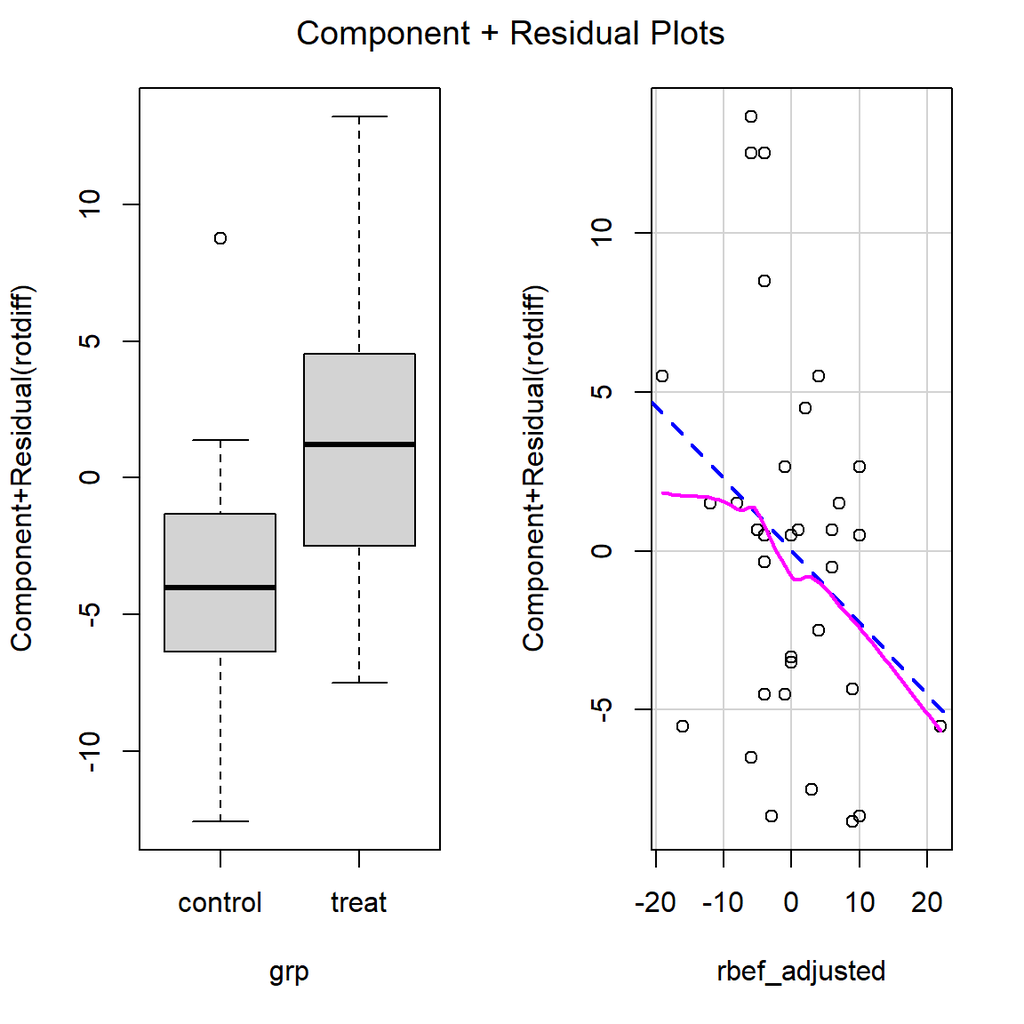

```r
# Calculate the mean of rbef for right hips
mean_rbef_right <- mean(hips2$rbef[hips2$side == "right"])

# Adjust the model by fixing rbef at its mean value
hips2$rbef_adjusted <- hips2$rbef - mean_rbef_right

# Re-fit the hip rotation model with the adjusted rbef
right_rot_bef_adjusted <- lm(rotdiff ~ grp + rbef_adjusted, data = hips2[hips2$side == "right",])

# Plot the partial residual plot for the adjusted model
crPlots(right_rot_bef_adjusted)
```

*The figure shows two component plus residual plots, which are helpful for diagnosing issues with a linear regression model.*

*The plot on the left side shows the relationship between the grouping variable grp (with levels “control” and “treat”) and the residuals from your linear model. This plot can be used to check if the residuals are evenly distributed across the levels of grp. If the boxes are symmetric and centered around zero, it suggests that the model is well-calibrated for each group. If one group has consistently higher or lower residuals, it might indicate that the model is not performing equally well for both groups.* *- The location of the median line within the boxes, which provides insight into the central tendency of the residuals within each group.* *- The length of the boxes and the whiskers, which give an idea about the variability within the groups.*

*The plot on the right side shows the relationship between the adjusted rbef variable and the residuals. The pink line suggests the LOESS (locally estimated scatterplot smoothing) fit to the data, which gives a sense of the trend. The LOESS line should be approximately horizontal and centered around zero if the relationship is linear and the model is appropriate. If the line shows a pattern (like a curve), this might suggest non-linearity, indicating that a linear model may not be the best fit for the data.* *In the plot on the right, the pink LOESS line is sloped and not horizontal, suggesting that the relationship between rbef and the response might be non-linear. Moreover, the residuals should be randomly scattered around the LOESS line without forming any discernible patterns and the patterns or the residuals are not centered around zero. This may indicate problems such as non-linearity, outliers, or non-constant variance.*

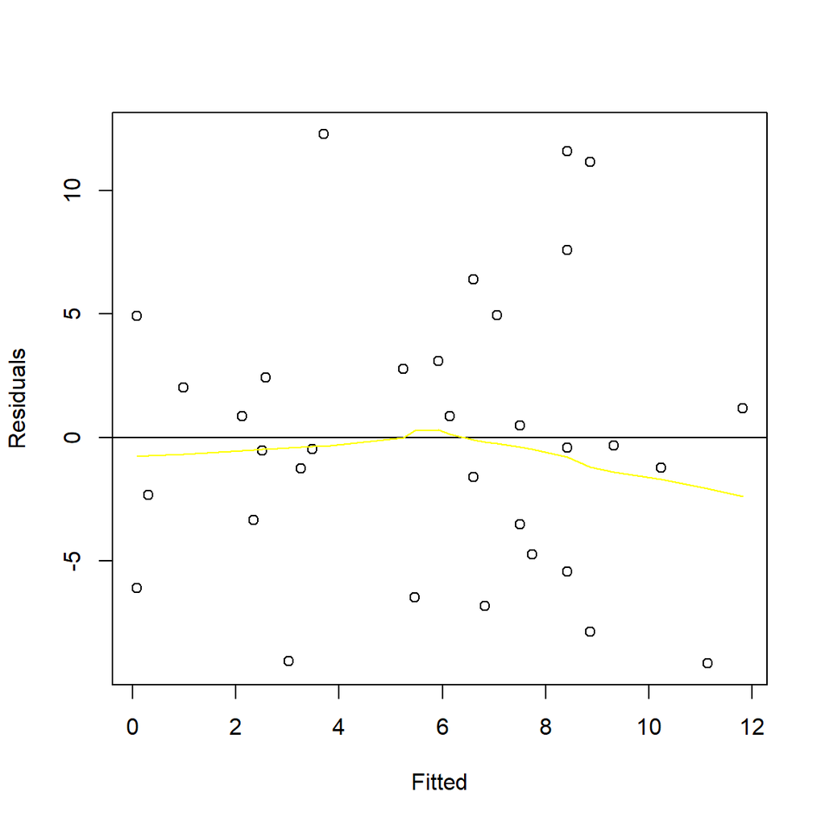

```r
# For a basic plot of the fitted values
# Assuming 'right_rot_bef_adjusted' is your model object
fit_values <- fitted(right_rot_bef_adjusted)
res_values <- residuals(right_rot_bef_adjusted)

# Create the plot
plot(fit_values, res_values, xlab = "Fitted", ylab = "Residuals")

# Add a horizontal line at 0
abline(h = 0)

# Fit a smooth curve (using LOESS) and add to the plot
smoothed_values <- lowess(fit_values, res_values)
lines(smoothed_values, col = "yellow")
```

*This residual plot is commonly used in regression analysis to check the assumption that the residuals are randomly distributed with constant variance (homoscedasticity). The yellow line representing a smoothed curve through the residuals. In an ideal scenario, this line would be flat and close to the horizontal line at zero, which would indicate that the model’s predictions are unbiased at every level of fitted values.* *If the residuals appear to be randomly scattered around the horizontal line without any systematic pattern, this indicates that the model’s assumptions are likely being met. In this case, the smoothed line shows a slight curve rather than being completely flat, it indicates that the residuals may not be perfectly randomly distributed.*

### Save and knit

**Reminder**: don’t forget to save this file and to knit it to check that everything works.

## Submit your assignment

When you have finished, and are satisfied with your assignment solutions, and this file knits without errors and the output looks the way you want, then you should upload both the .Rmd file and rendered (knitted) .html file to the assessment respective upload boxes in OL.